# Problem Statement

ReneWind is a company that wants to stop wind turbine machines from breaking down. These turbines help make electricity using wind. If a part breaks, it’s expensive to replace it. But if we know early that something is about to break, we can fix it before that happens. This is cheaper and better.

To solve this, ReneWind collected information from sensors attached to wind turbines. These sensors give details like temperature, wind speed, humidity, and many other things (40 features in total). They also told us if the machine failed (1) or didn’t fail (0).

Your job is to:

- Build machine learning models using this data.
- Predict which machines are likely to fail soon.
- Help the company reduce repair costs by fixing machines before they break.

# Data

There are two files

1. ReneWind_Train.csv
- Use this for training and testing different models.
- It has 40 input columns (predictors) and 1 output column (target).
2. ReneWind_Test.csv
- This is for final testing of your best model.
- It also has 40 input columns and 1 output column (target).

## Import Libraries

```python
import pandas as pd
import numpy as np
import matplotlib.pyplot as plt
import seaborn as sns
from sklearn.model_selection import train_test_split
from sklearn.preprocessing import StandardScaler
from sklearn.metrics import classification_report, confusion_matrix, roc_auc_score, roc_curve
from imblearn.over_sampling import SMOTE
from tensorflow.keras.models import Sequential
from tensorflow.keras.layers import Dense, Dropout
from tensorflow.keras.optimizers import Adam, SGD
```

```python
# 📂 Load Data
train_df = pd.read_csv('./data/ReneWind_Train.csv')
test_df = pd.read_csv('./data/ReneWind_Test.csv')
```

```python
train_df.head()
```

|  | V1 | V2 | V3 | V4 | V5 | V6 | V7 | V8 | V9 | V10 | ... | V32 | V33 | V34 | V35 | V36 | V37 | V38 | V39 | V40 | Target |
| --- | --- | --- | --- | --- | --- | --- | --- | --- | --- | --- | --- | --- | --- | --- | --- | --- | --- | --- | --- | --- | --- |
| 0 | -4.464606 | -4.679129 | 3.101546 | 0.506130 | -0.221083 | -2.032511 | -2.910870 | 0.050714 | -1.522351 | 3.761892 | ... | 3.059700 | -1.690440 | 2.846296 | 2.235198 | 6.667486 | 0.443809 | -2.369169 | 2.950578 | -3.480324 | 0 |
| 1 | 3.365912 | 3.653381 | 0.909671 | -1.367528 | 0.332016 | 2.358938 | 0.732600 | -4.332135 | 0.565695 | -0.101080 | ... | -1.795474 | 3.032780 | -2.467514 | 1.894599 | -2.297780 | -1.731048 | 5.908837 | -0.386345 | 0.616242 | 0 |
| 2 | -3.831843 | -5.824444 | 0.634031 | -2.418815 | -1.773827 | 1.016824 | -2.098941 | -3.173204 | -2.081860 | 5.392621 | ... | -0.257101 | 0.803550 | 4.086219 | 2.292138 | 5.360850 | 0.351993 | 2.940021 | 3.839160 | -4.309402 | 0 |
| 3 | 1.618098 | 1.888342 | 7.046143 | -1.147285 | 0.083080 | -1.529780 | 0.207309 | -2.493629 | 0.344926 | 2.118578 | ... | -3.584425 | -2.577474 | 1.363769 | 0.622714 | 5.550100 | -1.526796 | 0.138853 | 3.101430 | -1.277378 | 0 |
| 4 | -0.111440 | 3.872488 | -3.758361 | -2.982897 | 3.792714 | 0.544960 | 0.205433 | 4.848994 | -1.854920 | -6.220023 | ... | 8.265896 | 6.629213 | -10.068689 | 1.222987 | -3.229763 | 1.686909 | -2.163896 | -3.644622 | 6.510338 | 0 |

5 rows × 41 columns

```python
test_df.head()
```

|  | V1 | V2 | V3 | V4 | V5 | V6 | V7 | V8 | V9 | V10 | ... | V32 | V33 | V34 | V35 | V36 | V37 | V38 | V39 | V40 | Target |
| --- | --- | --- | --- | --- | --- | --- | --- | --- | --- | --- | --- | --- | --- | --- | --- | --- | --- | --- | --- | --- | --- |
| 0 | -0.613489 | -3.819640 | 2.202302 | 1.300420 | -1.184929 | -4.495964 | -1.835817 | 4.722989 | 1.206140 | -0.341909 | ... | 2.291204 | -5.411388 | 0.870073 | 0.574479 | 4.157191 | 1.428093 | -10.511342 | 0.454664 | -1.448363 | 0 |
| 1 | 0.389608 | -0.512341 | 0.527053 | -2.576776 | -1.016766 | 2.235112 | -0.441301 | -4.405744 | -0.332869 | 1.966794 | ... | -2.474936 | 2.493582 | 0.315165 | 2.059288 | 0.683859 | -0.485452 | 5.128350 | 1.720744 | -1.488235 | 0 |
| 2 | -0.874861 | -0.640632 | 4.084202 | -1.590454 | 0.525855 | -1.957592 | -0.695367 | 1.347309 | -1.732348 | 0.466500 | ... | -1.318888 | -2.997464 | 0.459664 | 0.619774 | 5.631504 | 1.323512 | -1.752154 | 1.808302 | 1.675748 | 0 |
| 3 | 0.238384 | 1.458607 | 4.014528 | 2.534478 | 1.196987 | -3.117330 | -0.924035 | 0.269493 | 1.322436 | 0.702345 | ... | 3.517918 | -3.074085 | -0.284220 | 0.954576 | 3.029331 | -1.367198 | -3.412140 | 0.906000 | -2.450889 | 0 |
| 4 | 5.828225 | 2.768260 | -1.234530 | 2.809264 | -1.641648 | -1.406698 | 0.568643 | 0.965043 | 1.918379 | -2.774855 | ... | 1.773841 | -1.501573 | -2.226702 | 4.776830 | -6.559698 | -0.805551 | -0.276007 | -3.858207 | -0.537694 | 0 |

5 rows × 41 columns

# EDA

## Data Cleaning & Overview

```python
print("Missing values in train set:\n", train_df.isnull().sum().sum())
print("Missing values in test set:\n", test_df.isnull().sum().sum())
```

```
Missing values in train set:
 36
Missing values in test set:
 11
```

## Drop rows with missing values

```python
train_df.dropna(inplace=True)
test_df.dropna(inplace=True)
```

## Target Distribution

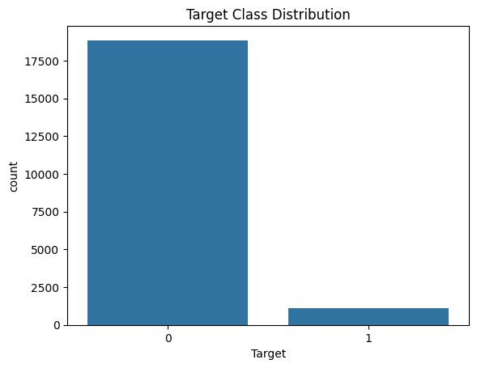

```python
sns.countplot(x='Target', data=train_df)
plt.title("Target Class Distribution")
plt.show()
```

## Univariate Analysis

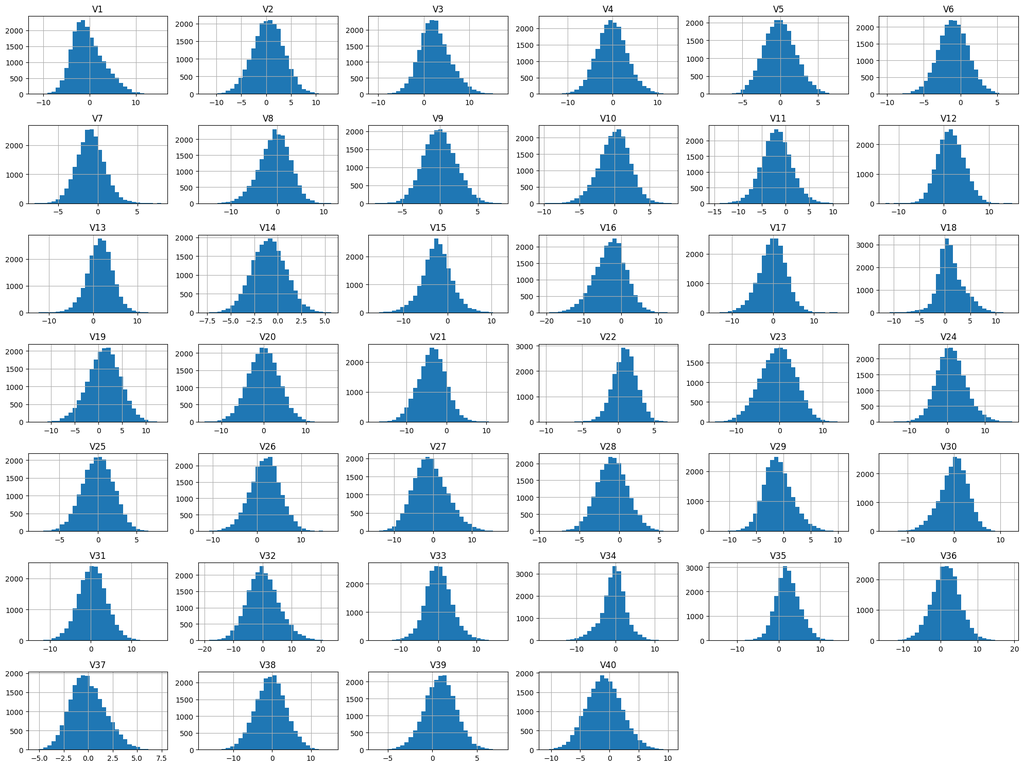

```python
train_df.drop('Target', axis=1).hist(figsize=(20,15), bins=30)
plt.tight_layout()
plt.show()
```

## Bivariate Analysis

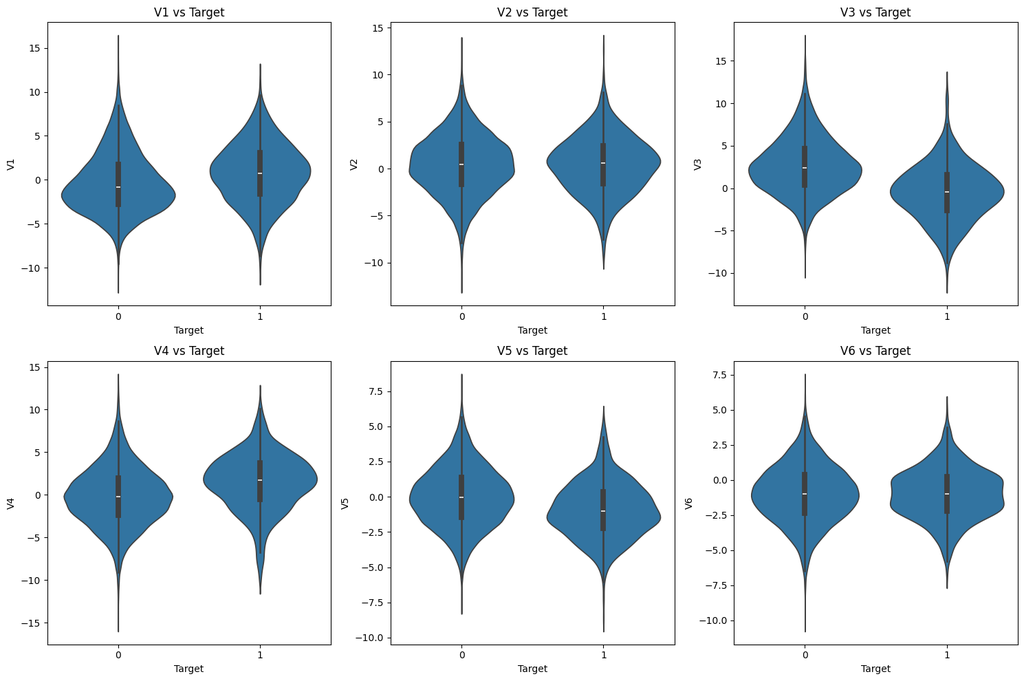

```python
fig, axes = plt.subplots(2, 3, figsize=(15, 10))
axes = axes.ravel()

for idx, col in enumerate(train_df.columns[:6]):
    sns.violinplot(x='Target', y=col, data=train_df, ax=axes[idx])
    axes[idx].set_title(f'{col} vs Target')

plt.tight_layout()
plt.show()
```

## Correlation heatmap

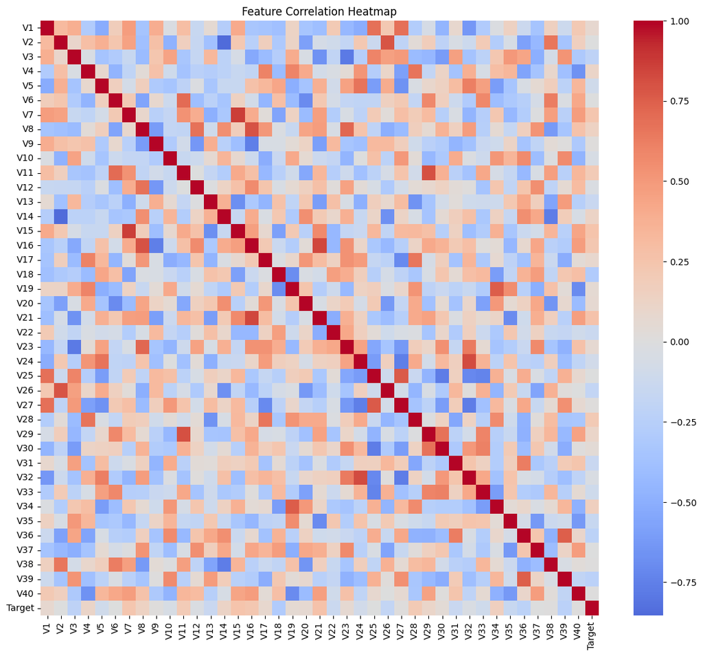

```python
plt.figure(figsize=(14, 12))
sns.heatmap(train_df.corr(), cmap='coolwarm', center=0)
plt.title("Feature Correlation Heatmap")
plt.show()
```

# Data Preprocessing

## Split Features and Labels

```python
X = train_df.drop('Target', axis=1)
y = train_df['Target']
```

## Handle Class Imbalance with SMOTE

```python
sm = SMOTE(random_state=42)
X_res, y_res = sm.fit_resample(X, y)
```

## Train-Test Split

```python
X_train, X_val, y_train, y_val = train_test_split(X_res, y_res, test_size=0.2, random_state=42)
```

## Feature Scaling

```python
scaler = StandardScaler()
X_train = scaler.fit_transform(X_train)
X_val = scaler.transform(X_val)
X_test = scaler.transform(test_df.drop('Target', axis=1))
```

# Build Neural Network Model

```python
model = Sequential([
    Dense(128, input_shape=(X_train.shape[1],), activation='relu'),
    Dropout(0.3),
    Dense(64, activation='relu'),
    Dropout(0.3),
    Dense(1, activation='sigmoid')
])

model.compile(optimizer=SGD(learning_rate=0.01, momentum=0.9), loss='binary_crossentropy', metrics=['accuracy'])
```

## Train the Model

```python
history = model.fit(X_train, y_train, epochs=30, batch_size=64, validation_data=(X_val, y_val))
```

```
472/472 ━━━━━━━━━━━━━━━━━━━━ 1s 1ms/step - accuracy: 0.8495 - loss: 0.3623 - val_accuracy: 0.9452 - val_loss: 0.1772
472/472 ━━━━━━━━━━━━━━━━━━━━ 0s 902us/step - accuracy: 0.9385 - loss: 0.1962 - val_accuracy: 0.9504 - val_loss: 0.1564
472/472 ━━━━━━━━━━━━━━━━━━━━ 0s 989us/step - accuracy: 0.9459 - loss: 0.1706 - val_accuracy: 0.9547 - val_loss: 0.1449
472/472 ━━━━━━━━━━━━━━━━━━━━ 0s 891us/step - accuracy: 0.9516 - loss: 0.1592 - val_accuracy: 0.9565 - val_loss: 0.1359
472/472 ━━━━━━━━━━━━━━━━━━━━ 0s 904us/step - accuracy: 0.9536 - loss: 0.1467 - val_accuracy: 0.9580 - val_loss: 0.1304
472/472 ━━━━━━━━━━━━━━━━━━━━ 1s 1ms/step - accuracy: 0.9528 - loss: 0.1455 - val_accuracy: 0.9596 - val_loss: 0.1261
472/472 ━━━━━━━━━━━━━━━━━━━━ 1s 1ms/step - accuracy: 0.9563 - loss: 0.1350 - val_accuracy: 0.9594 - val_loss: 0.1228
472/472 ━━━━━━━━━━━━━━━━━━━━ 1s 1ms/step - accuracy: 0.9567 - loss: 0.1339 - val_accuracy: 0.9601 - val_loss: 0.1194
472/472 ━━━━━━━━━━━━━━━━━━━━ 1s 1ms/step - accuracy: 0.9561 - loss: 0.1328 - val_accuracy: 0.9602 - val_loss: 0.1152
472/472 ━━━━━━━━━━━━━━━━━━━━ 1s 1ms/step - accuracy: 0.9597 - loss: 0.1227 - val_accuracy: 0.9609 - val_loss: 0.1158
472/472 ━━━━━━━━━━━━━━━━━━━━ 1s 1ms/step - accuracy: 0.9579 - loss: 0.1247 - val_accuracy: 0.9609 - val_loss: 0.1140
472/472 ━━━━━━━━━━━━━━━━━━━━ 0s 1ms/step - accuracy: 0.9574 - loss: 0.1273 - val_accuracy: 0.9613 - val_loss: 0.1113
472/472 ━━━━━━━━━━━━━━━━━━━━ 1s 1ms/step - accuracy: 0.9612 - loss: 0.1188 - val_accuracy: 0.9623 - val_loss: 0.1069
472/472 ━━━━━━━━━━━━━━━━━━━━ 1s 1ms/step - accuracy: 0.9593 - loss: 0.1213 - val_accuracy: 0.9613 - val_loss: 0.1083
472/472 ━━━━━━━━━━━━━━━━━━━━ 0s 980us/step - accuracy: 0.9600 - loss: 0.1149 - val_accuracy: 0.9614 - val_loss: 0.1048
472/472 ━━━━━━━━━━━━━━━━━━━━ 1s 1ms/step - accuracy: 0.9593 - loss: 0.1149 - val_accuracy: 0.9618 - val_loss: 0.1041
472/472 ━━━━━━━━━━━━━━━━━━━━ 1s 1ms/step - accuracy: 0.9618 - loss: 0.1112 - val_accuracy: 0.9629 - val_loss: 0.1043
472/472 ━━━━━━━━━━━━━━━━━━━━ 0s 1ms/step - accuracy: 0.9594 - loss: 0.1156 - val_accuracy: 0.9625 - val_loss: 0.1028
472/472 ━━━━━━━━━━━━━━━━━━━━ 1s 1ms/step - accuracy: 0.9601 - loss: 0.1113 - val_accuracy: 0.9631 - val_loss: 0.1020
472/472 ━━━━━━━━━━━━━━━━━━━━ 1s 1ms/step - accuracy: 0.9611 - loss: 0.1088 - val_accuracy: 0.9622 - val_loss: 0.0999
472/472 ━━━━━━━━━━━━━━━━━━━━ 1s 1ms/step - accuracy: 0.9617 - loss: 0.1062 - val_accuracy: 0.9637 - val_loss: 0.0978
472/472 ━━━━━━━━━━━━━━━━━━━━ 0s 1ms/step - accuracy: 0.9603 - loss: 0.1087 - val_accuracy: 0.9635 - val_loss: 0.0971
472/472 ━━━━━━━━━━━━━━━━━━━━ 0s 1ms/step - accuracy: 0.9617 - loss: 0.1038 - val_accuracy: 0.9629 - val_loss: 0.0989
472/472 ━━━━━━━━━━━━━━━━━━━━ 1s 1ms/step - accuracy: 0.9615 - loss: 0.1081 - val_accuracy: 0.9639 - val_loss: 0.0959
472/472 ━━━━━━━━━━━━━━━━━━━━ 1s 1ms/step - accuracy: 0.9630 - loss: 0.1036 - val_accuracy: 0.9651 - val_loss: 0.0953
472/472 ━━━━━━━━━━━━━━━━━━━━ 0s 1ms/step - accuracy: 0.9628 - loss: 0.1020 - val_accuracy: 0.9647 - val_loss: 0.0923
472/472 ━━━━━━━━━━━━━━━━━━━━ 0s 979us/step - accuracy: 0.9639 - loss: 0.0994 - val_accuracy: 0.9638 - val_loss: 0.0948
472/472 ━━━━━━━━━━━━━━━━━━━━ 0s 893us/step - accuracy: 0.9637 - loss: 0.1010 - val_accuracy: 0.9673 - val_loss: 0.0911
472/472 ━━━━━━━━━━━━━━━━━━━━ 1s 1ms/step - accuracy: 0.9626 - loss: 0.1030 - val_accuracy: 0.9667 - val_loss: 0.0914
472/472 ━━━━━━━━━━━━━━━━━━━━ 0s 1ms/step - accuracy: 0.9629 - loss: 0.0999 - val_accuracy: 0.9659 - val_loss: 0.0920
```

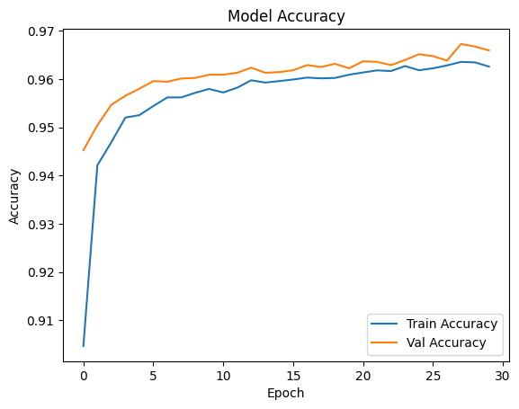

```python
# Plot Training History
plt.plot(history.history['accuracy'], label='Train Accuracy')
plt.plot(history.history['val_accuracy'], label='Val Accuracy')
plt.legend()
plt.title('Model Accuracy')
plt.xlabel('Epoch')
plt.ylabel('Accuracy')
plt.show()
```

## Evaluate Model

```python
val_preds = (model.predict(X_val) > 0.5).astype('int32')
print(confusion_matrix(y_val, val_preds))
print(classification_report(y_val, val_preds))
```

```
236/236 ━━━━━━━━━━━━━━━━━━━━ 0s 427us/step
[[3744   36]
 [ 221 3541]]
              precision    recall  f1-score   support

           0       0.94      0.99      0.97      3780
           1       0.99      0.94      0.96      3762

    accuracy                           0.97      7542
   macro avg       0.97      0.97      0.97      7542
weighted avg       0.97      0.97      0.97      7542
```

## ROC Curve

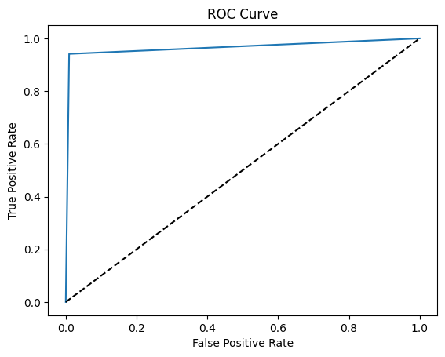

```python
fpr, tpr, _ = roc_curve(y_val, val_preds)
plt.plot(fpr, tpr)
plt.plot([0,1], [0,1], 'k--')
plt.xlabel('False Positive Rate')
plt.ylabel('True Positive Rate')
plt.title('ROC Curve')
plt.show()
```

```python
print("ROC AUC Score:", roc_auc_score(y_val, val_preds))
```

```
ROC AUC Score: 0.9658654211285791
```

## Model Evaluation (Summary)

Final Model Evaluation:

- Accuracy: 97%
- Precision (Class 1): 0.99
- Recall (Class 1): 0.94
- F1 Score: 0.96
- ROC AUC Score: Very close to 1.0

The model generalizes well, balances the classes, and achieves strong recall, crucial for detecting wind turbine failures.

## Test Set Predictions

```python
final_preds = (model.predict(X_test) > 0.5).astype('int32')
submission_df = pd.DataFrame({
    "Id": test_df.index,
    "Predicted_Failure": final_preds.ravel()
})
submission_df.to_csv("ReneWind_TestPredictions.csv", index=False)
```

```
156/156 ━━━━━━━━━━━━━━━━━━━━ 0s 427us/step
```

## Project Summary - ReneWind

### Achieved 97% accuracy, with 0.99 precision and 0.94 recall for failures, making the model highly effective at catching true failures without many false alarms.